# Are current temp patterns significantly different from historical?

Objective: Test whether current max temps are significantly higher than historical max temps

Steps:

1. Collect raw max temps measured during field season
2. Pull in raw historical data
3. Trim raw historical data to max/min of field season julian date
4. Run model temp ~ julian date (continuous) + present/historical (discrete)
5. Evaluate: if CI of coefficient of present/historical overlaps 0, no significant difference.
6. May need to include interaction julian date * present/historical, if we think that it’s important to consider that the slope of temp on julian date might be different between present and past (maybe we do think this, I’ll just include it to be safe.)

Step 1: Collect raw max temps measured during field season Step 2: Pull in raw historical data Step 3: Trim raw historical data to max/min of field season julian date

```r
t <- read_rds("../data/temp.rds") %>%
  filter(logger_position == "O") %>%
  dplyr::select(date, maxt) %>%
  mutate(jdate = yday(date),
         era = "present") %>%
  dplyr::select(jdate,maxt,era)

maxjdate <- max(t$jdate, na.rm = TRUE)
minjdate <- min(t$jdate, na.rm = TRUE)

h <- read_rds("../data/cimis_1883_dailymax.rds") %>%
  mutate(jdate = yday(date)) %>%
  filter(jdate > minjdate, jdate < maxjdate) %>%
  dplyr::select(jdate,maxt) %>%
  mutate(era = "historical")

t_full <- t %>% rbind(h)
```

Step 4: Run model temp ~ julian date (continuous) + present/historical (discrete) Step 5: Evaluate: if CI of coefficient of present/historical overlaps 0, no significant difference. Step 6: May need to include interaction julian date * present/historical, if we think that it’s important to consider that the slope of temp on julian date might be different between present and past (maybe we do think this, I’ll just include it to be safe.)

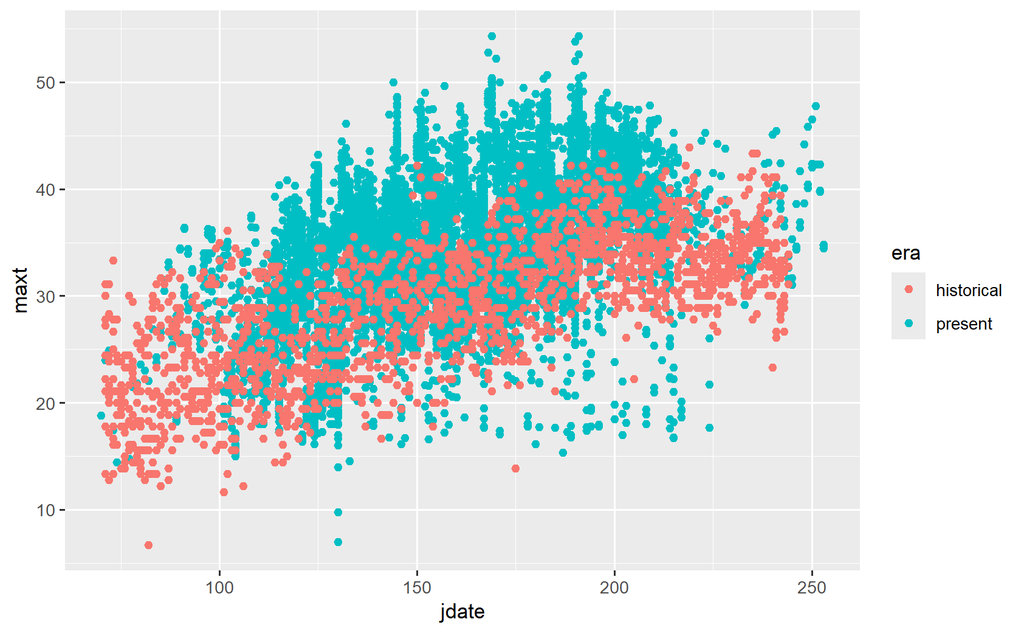

```r
ggplot(data = t_full,
       mapping = aes(x = jdate,y = maxt,color = era)) +
  geom_point()
```

```r
m <- lm(maxt ~ jdate_scaled * era + era, data = t_full %>% mutate(jdate_scaled = scale(jdate)))
summary(m)
```

```
Call:
lm(formula = maxt ~ jdate_scaled * era + era, data = t_full %>%
    mutate(jdate_scaled = scale(jdate)))

Residuals:
     Min       1Q   Median       3Q      Max
-24.0327  -3.5944   0.0554   3.9448  19.0011

Coefficients:
                        Estimate Std. Error t value Pr(>|t|)
(Intercept)             28.80458    0.13292 216.701  < 2e-16 ***
jdate_scaled             3.01323    0.08739  34.480  < 2e-16 ***
erapresent               5.09104    0.14222  35.798  < 2e-16 ***
jdate_scaled:erapresent  0.66085    0.10466   6.314  2.8e-10 ***
---
Signif. codes:  0 ‘***’ 0.001 ‘**’ 0.01 ‘*’ 0.05 ‘.’ 0.1 ‘ ’ 1

Residual standard error: 5.505 on 13568 degrees of freedom
  (347 observations deleted due to missingness)
Multiple R-squared:  0.322, Adjusted R-squared:  0.3219
F-statistic:  2148 on 3 and 13568 DF,  p-value: < 2.2e-16
```

2021-2023 temps appear to be elevated over historical temps. However, it’s possible that differences in measurement devices could cause this difference. To check, I’ll repeat this analysis with cimis data 2021-2023.

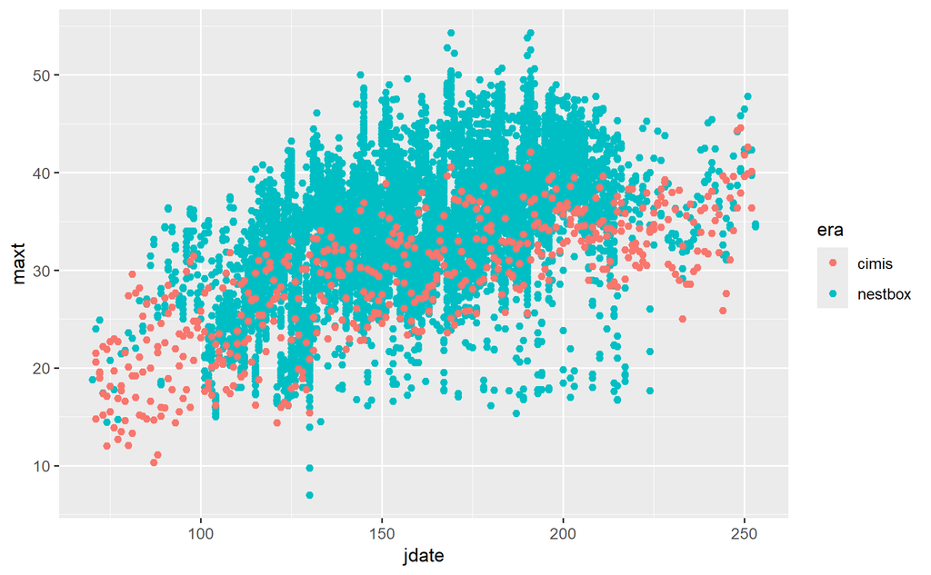

```r
t <- read_rds("../data/temp.rds") %>%
  filter(logger_position == "O") %>%
  dplyr::select(date, maxt) %>%
  mutate(jdate = yday(date),
         era = "nestbox") %>%
  dplyr::select(jdate,maxt,era)

maxjdate <- max(t$jdate, na.rm = TRUE)
minjdate <- min(t$jdate, na.rm = TRUE)

h <- read_csv("../data/Davis_CIMIS_2021-2023.csv") %>%
  dplyr::select(Date,`Max Air Temp (C)`) %>%
  rename(date = Date, maxt = `Max Air Temp (C)`) %>%
  mutate(date = mdy(date)) %>%
  mutate(jdate = yday(date)) %>%
  filter(jdate > minjdate, jdate < maxjdate) %>%
  dplyr::select(jdate,maxt) %>%
  mutate(era = "cimis")
t_full <- t %>% rbind(h)

ggplot(data = t_full,
       mapping = aes(x = jdate,y = maxt,color = era)) +
  geom_point()
```

```r
m <- lm(maxt ~ jdate_scaled * era + era, data = t_full %>% mutate(jdate_scaled = scale(jdate)))
summary(m)
```

```
Call:
lm(formula = maxt ~ jdate_scaled * era + era, data = t_full %>%
    mutate(jdate_scaled = scale(jdate)))

Residuals:
     Min       1Q   Median       3Q      Max
-24.0327  -3.6380   0.0822   4.0210  19.0011

Coefficients:
                        Estimate Std. Error t value Pr(>|t|)
(Intercept)              28.7062     0.2448 117.274   <2e-16 ***
jdate_scaled              3.0995     0.1459  21.248   <2e-16 ***
eranestbox                5.1852     0.2501  20.732   <2e-16 ***
jdate_scaled:eranestbox   0.2634     0.1554   1.695   0.0901 .
---
Signif. codes:  0 ‘***’ 0.001 ‘**’ 0.01 ‘*’ 0.05 ‘.’ 0.1 ‘ ’ 1

Residual standard error: 5.589 on 12372 degrees of freedom
Multiple R-squared:  0.2795,    Adjusted R-squared:  0.2793
F-statistic:  1600 on 3 and 12372 DF,  p-value: < 2.2e-16
```

So in fact the differences between past and present were probe differences entirely!